# Horror Legends

data from: rfordatascience/tidytuesday

Author

Federico Alegría

[figure not shown]

## Horror Legends

For {tidytuesdayR} `tt_load(2023, week = 44)`, we were given some data from Snopes, a [fact-checking](https://en.wikipedia.org/wiki/Fact_checking) website created by David and Barbara Mikkelson that has been described as a

> “well-regarded reference for sorting out myths and rumors” on the Internet. The site has also been seen as a source for both validating and [debunking](https://en.wikipedia.org/wiki/Debunker) [urban legends](https://en.wikipedia.org/wiki/Urban_legend) and similar stories in [American popular culture](https://en.wikipedia.org/wiki/Culture_of_the_United_States).

### Ratings

Here, we can spot how many of these have been rated as “Legend” & “True”:

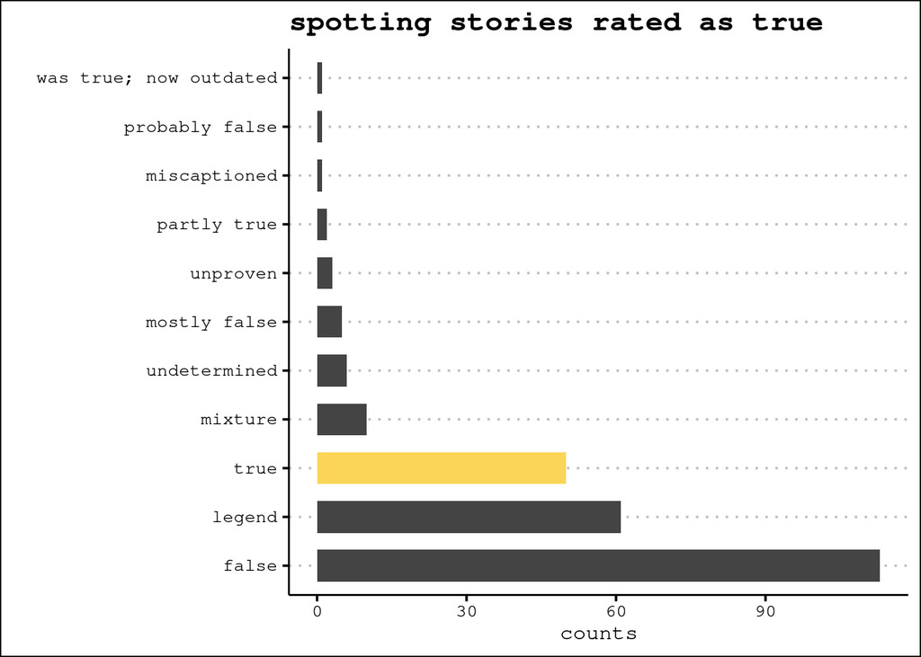

```r
df |>
  group_by(rating) |>
  count(rating) |>
  ggplot(aes(
    x = n,
    y = reorder(rating, desc(n)),
    fill = rating == "true"
  )) +
  geom_bar(stat = "identity",
           width = 0.65) +
  scale_fill_manual(values = c("#444444",
                               "#fbd558")) +
  guides(fill = "none") +
  labs(x = "counts",
       y = "",
       title = "spotting stories rated as true") +
  theme_clean(base_size = 14,
              base_family = "mono")
```

Truthful ratings sum 50 events, and such folklore indicates our deepest fears in ways like these:

> - We worry about the terrible accidents we’re powerless to prevent, and we fear anonymous killers who choose victims at random.
> - We cannot protect ourselves from the venomous animals who slither undetected into the places where we work, play, and shop, nor can we stop the onslaught of insects who invade our homes and our bodies.
> - We’re repulsed by the contaminants that may lurk in our food.
> - We’re afraid of foreigners and foreign places.
> - We fear for our childrens’ safety in a world full of drugs, kidnappers, and poisons.
> - We never know what gruesome discovery may be waiting around the next corner.
> - And even if we somehow escape all of these horrors, our own vanities may do us in.

Following an accountable logic, I decided to explore the stories about `accidents`, `killings`, `animals`, `poisonings`, `foreignness`, `threats`, `unknown` and `vanity` published at Snopes, but written by its founders; the Mikkelsons. This leaves a pool of 40 pieces:

```r
df |>
  filter(
    author == "Barbara Mikkelson" | author == "David Mikkelson",
    rating == "true"
  ) |>
  group_by(author, rating) |>
  summarise(n = n()) |>
  adorn_totals(where = "row") |>
  knitr::kable()
```

| author | rating | n |
| --- | --- | --- |
| Barbara Mikkelson | true | 28 |
| David Mikkelson | true | 12 |
| Total | - | 40 |

The following tag or word cloud, illustrates most frequent text data found in all titles from the 40 instances rated as true by the Mikkelson couple:

```r
df |>
  filter(
    author == "Barbara Mikkelson" | author == "David Mikkelson",
    rating == "true"
  ) |>
  unnest_tokens(output = word, input = title) |>
  anti_join(stop_words, by = "word") |>
  filter(str_length(word) >= 2) |>
  group_by(word) |>
  summarise(n = n()) |>
  arrange(desc(n)) |>
  wordcloud2(
    backgroundColor = "#444444",
    color = "#fbd558",
    rotateRatio = 0
  )
```

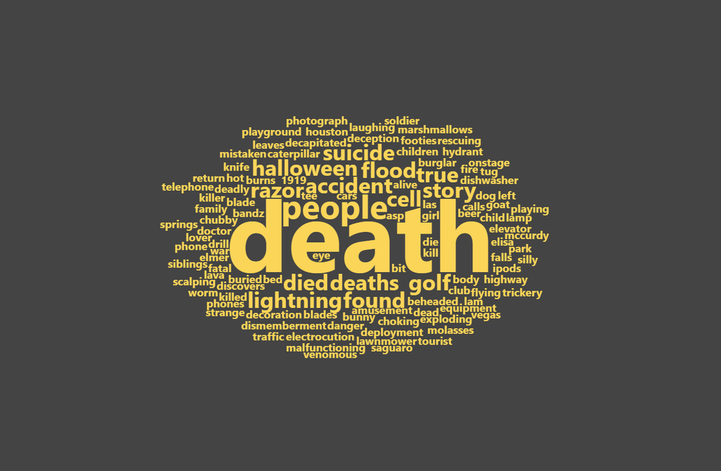

## Let’s read!

For a pleasant reading experience, we’ll need a `*.txt` output

```r
sink(file = "/cloud/project/TT2023_44/output.txt")

df |>
  filter(
    author == "Barbara Mikkelson" |
      author == "David Mikkelson",
    rating == "legend" |
      rating == "true"
  ) |>
  select(author, rating, title, subtitle, claim) |>
  map(glimpse)

sink(file = NULL)
```

`output.txt` was cleaned in Sublime Text[^1] by using a “Find and Replace” method (`Ctrl`+`H`) for double space strings where “∙∙” was found and replaced with a null character. Afterwards, it was imported as a *.qda project in QualCoder version 3.3 and coded as follows:

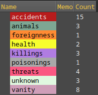

$claim

[1] "A father drove his truck over a leaf pile containing his daughter, killing her."

[2] "A man was burned to death attempting to rescue his friend's dog from a boiling hot spring."

[3] "Nine people died in a beer flood in 1814."

[4] "A young woman named Elisa Lam disappeared under mysterious circumstances in Los Angeles, her body later found in a hotel's water tank."

[5] "Photographs show a venomous caterpillar known as an asp."

[6] "Razor blades were discovered glued to playground equipment in a public park."

[7] "A burglar discovered a suicide in the home he'd broken into."

[8] "A razor blade discovered in a child's \"footies\" (footed pajamas) injured a baby."

[9] "A child injured his arm through extended wearing of Silly Bandz."

[10] "A soldier returning from deployment discovered his wife had died during his absence, and their children had starved to death."

[11] "A man's cell phone placed calls to his loved ones after his demise."

[12] "A golfer angered by a bad shot was killed by the club he threw in frustration."

[13] "A man was killed by an exploding lava lamp."

[14] "A spectator at a football game was killed by a flying model lawnmower."

[15] "The presence of electronic devices (such as iPods and cell phones) on one's body can make lightning strike injuries more severe."

[16] "A pedestrian was killed by a flying fire hydrant."

[17] "Several actors have kicked the bucket in front of an audience."

[18] "A child suffocated while playing a \"Chubby Bunny\" marshmallow-stuffing game."

[19] "Bodies of suicide victims have been mistaken for Halloween decorations."

[20] "Lightning strikes have killed people who were talking on the telephone."

[21] "People have died laughing."

[22] "A Houston doctor was decapitated by a malfunctioning elevator."

[23] "A construction worker survived an accident that poked an 18-inch-long drill bit through one eye and out the side of his skull."

[24] "A tourist was electrocuted while crossing a street in Las Vegas."

[25] "Child falls on knife in open dishwasher and dies."

[26] "The larva of a human botfly was removed from a child's eye."

[27] "Siblings are coincidentally killed in related automobile accidents."

[28] "Woman fabricates story about being detained by a man pretending to be a police officer."

[29] "A girl on an amusement park ride was scalped when her hair got caught in the attraction's machinery."

[30] "Baby left in car by forgetful parent dies."

[31] "A damaged saguaro cactus fell onto the man who had harmed it and killed him."

[32] "A cuckolded husband presented his wife with the head of her lover."

[33] "Halloween hanging stunt goes wrong and hangs a man for real."

[34] "A vacationing couple staying in a foul-smelling motel room discovered a body hidden under their bed."

[35] "People have been buried alive by mistake."

[36] "A fatal wave of molasses swept through Boston in January 1919."

[37] "An abused goat kills its owner ... and then is saved from destruction by animal lovers."

[38] "The \"hanging man\" in a funhouse turns out to be the corpse of an outlaw."

[39] "A photograph shows the aftermath of a grisly tug-of-war contest in which two men lost their arms."

[40] "A golfer in the habit of carrying his tee in his mouth while playing holes grows sicker and sicker over the course of a few days and then drops dead. A post-mortem reveals that the golfer had ingested a lethal dose of the pesticide sprayed on the golf course."

Coding was performed manually and has been resumed in the following truncated list:

```r
df |>
  filter(author == "Barbara Mikkelson" |
           author == "David Mikkelson") |>
  filter(rating == "true") |>
  select(claim) |>
  map( ~ str_trunc(.x, width = 70, side = "right"))
# the markdown table was manually rendered at
# https://www.tablesgenerator.com/markdown_tables
```

| **claim** | **category** |
| --- | --- |
| [01] “A father drove his truck over a leaf pile containing his daughter, …” | **accident** |
| [02] “A man was burned to death attempting to rescue his friend’s dog fro…” | **accident** |
| [03] “Nine people died in a beer flood in 1814.” | **accident** |
| [04] “A young woman named Elisa Lam disappeared under mysterious circumst…” | **unknown** |
| [05] “Photographs show a venomous caterpillar known as an asp.” | **animal** |
| [06] “Razor blades were discovered glued to playground equipment in a pub…” | **threat** |
| [07] “A burglar discovered a suicide in the home he’d broken into.” | **vanity** |
| [08] “A razor blade discovered in a child’s”footies” (footed pajamas) in…” | **threat** |
| [09] “A child injured his arm through extended wearing of Silly Bandz.” | **accident** |
| [10] “A soldier returning from deployment discovered his wife had died du…” | **health** |
| [11] “A man’s cell phone placed calls to his loved ones after his demise.” | **unknown** |
| [12] “A golfer angered by a bad shot was killed by the club he threw in f…” | **vanity** |
| [13] “A man was killed by an exploding lava lamp.” | **accident** |
| [14] “A spectator at a football game was killed by a flying model lawnmower.” | **accident** |
| [15] “The presence of electronic devices (such as iPods and cell phones) …” | **threat** |
| [16] “A pedestrian was killed by a flying fire hydrant.” | **accident** |
| [17] “Several actors have kicked the bucket in front of an audience.” | **health** |
| [18] “A child suffocated while playing a”Chubby Bunny” marshmallow-stuff…” | **vanity** |
| [19] “Bodies of suicide victims have been mistaken for Halloween decorati…” | **killing** |
| [20] “Lightning strikes have killed people who were talking on the teleph…” | **threat** |
| [21] “People have died laughing.” | **unknown** |
| [22] “A Houston doctor was decapitated by a malfunctioning elevator.” | **accident** |
| [23] “A construction worker survived an accident that poked an 18-inch-lo…” | **accident** |
| [24] “A tourist was electrocuted while crossing a street in Las Vegas.” | **accident** |
| [25] “Child falls on knife in open dishwasher and dies.” | **accident** |
| [26] “The larva of a human botfly was removed from a child’s eye.” | **animal** |
| [27] “Siblings are coincidentally killed in related automobile accidents.” | **accident** |
| [28] “Woman fabricates story about being detained by a man pretending to …” | **vanity** |
| [29] “A girl on an amusement park ride was scalped when her hair got caug…” | **accident** |
| [30] “Baby left in car by forgetful parent dies.” | **killing** |
| [31] “A damaged saguaro cactus fell onto the man who had harmed it and ki…” | **vanity** |
| [32] “A cuckolded husband presented his wife with the head of her lover.” | **killing** |
| [33] “Halloween hanging stunt goes wrong and hangs a man for real.” | **vanity** |
| [34] “A vacationing couple staying in a foul-smelling motel room discover…” | **foreign** |
| [35] “People have been buried alive by mistake.” | **accident** |
| [36] “A fatal wave of molasses swept through Boston in January 1919.” | **accident** |
| [37] “An abused goat kills its owner … and then is saved from destructi…” | **animal** |
| [38] “The”hanging man” in a funhouse turns out to be the corpse of an ou…” | **vanity** |
| [39] “A photograph shows the aftermath of a grisly tug-of-war contest in …” | **vanity** |
| [40] “A golfer in the habit of carrying his tee in his mouth while playin…” | **poisoning** |

`health` wasn’t a category from Snopes’ definition thus was aggregated by myself. The following bar plot highlights the most frequent coding, accidents:

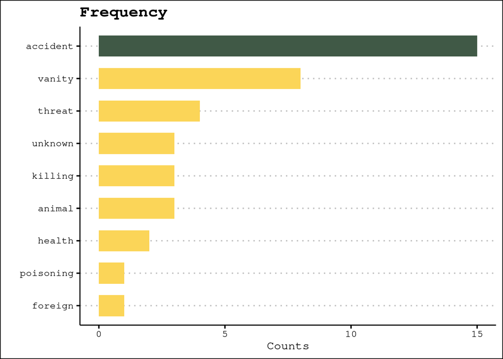

```r
freq <- tribble(
  ~code, ~total,
  "accident", 15,
  "vanity", 8,
  "threat", 4,
  "animal", 3,
  "killing", 3,
  "unknown", 3,
  "health", 2,
  "foreign", 1,
  "poisoning", 1
)

# barplot for frequencies
freq |>
  ggplot(aes(
    x = total,
    y = reorder(code, total),
    fill = code
  )) +
  geom_bar(stat = "identity",
           width = 0.65) +
  guides(fill = "none") +
  scale_fill_manual(
    values = c(
      accident = "#405946",
      animal = "#fbd558",
      foreign = "#fbd558",
      health = "#fbd558",
      killing = "#fbd558",
      poisoning = "#fbd558",
      threat = "#fbd558",
      unknown = "#fbd558",
      vanity = "#fbd558"
    )
  ) +
  labs(x = "Counts",
       y = "",
       title = "Frequency") +
  theme_clean(base_size = 14,
              base_family = "mono")
```

Finally, here’s a personal summarised-selection of the 5 most odd accidents from the evaluated list:

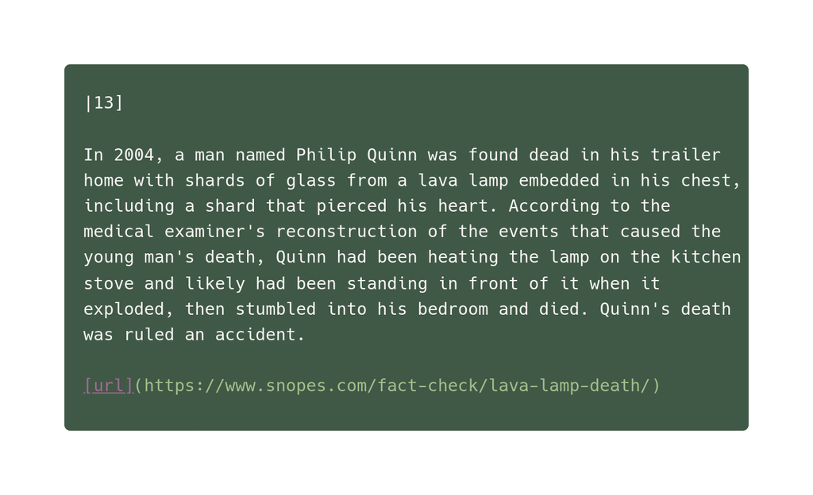

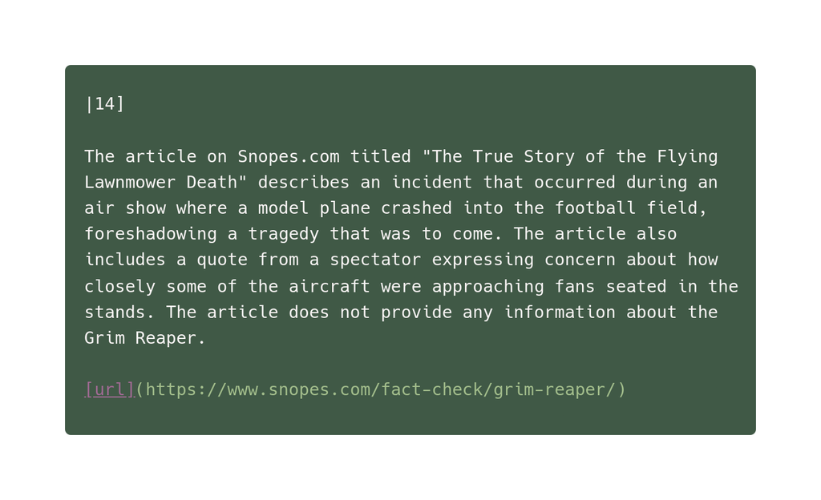

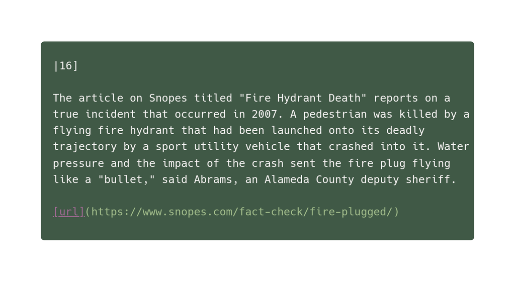

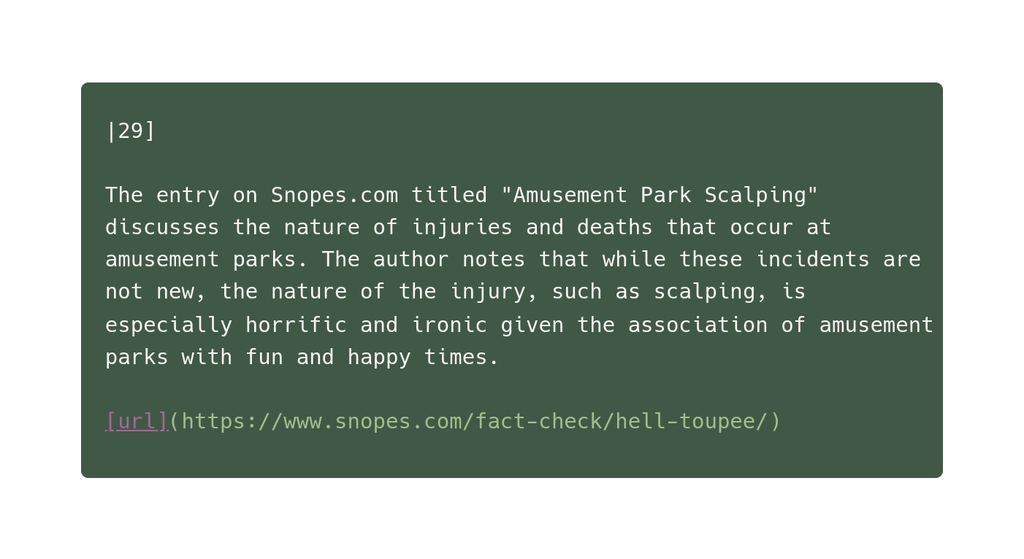

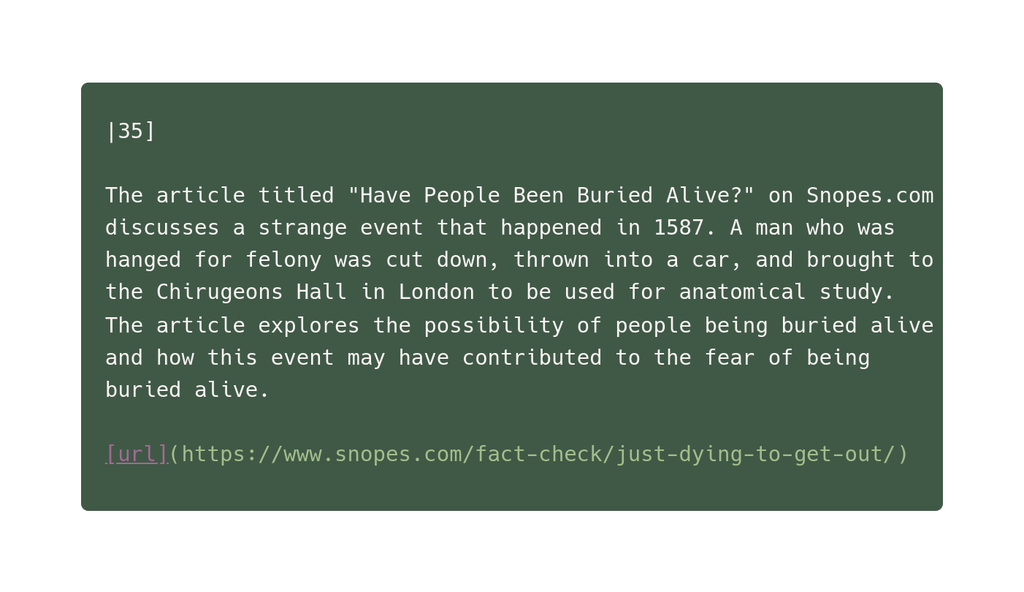

The stories where summarised by [Perplexity](https://www.perplexity.ai/)’s base model and the images where manually rendered at https://carbon.now.sh/. The prompt used at perplexity was:

```markdown
Can you give me a 50 words summary of the following entry please?
[[url]]
```

## Footnotes

[^1]: Build 4152, Unregistered